# Forecasting the Global Price of Metal Index using ARIMA Model

*Abstract*:

Given the importance of metal to world economy, governments, corporations, and individual investors, it is vital that their future movements are predicted and managed. One way of forecasting metal prices at a global level is to use global data. One such series is the “PMETAINDEXM” (Federal Reserve Economic Data - FRED) for the Global Price of Metal Index (base metals). Using a time series model ARIMA (p,d,q), this paper adequately estimates and makes a 6 moth ahead forecast of the series. The Box-Jinkins method is used to identify, estimate, evaluate, and forecast the time series.

**Introduction:**

Metals are of great importance to the world economy today. Not only today, but metals have been one of the main fuelers of economic production for most of the recent human history. It is even safe to declare that that the industrial revolution of the 19th and 20th centuries in Great Britain and the United States were mainly fueled by metals (iron and steel). Although oil prices remain the center of attention when it comes to commodity price watchers, metal prices also require that we watch out for them. Dictated by the laws of economic demand and supply, the prices of metals demand special attention by almost all economies and industries. Today, in a widely connected world where most industries depend on global supply chains, it becomes important to assess the prices of metals at a global level. One of the main indicators used to follow the price of metals is the Global Price of Metal Index (FRED code: PMETAINDEXM). This index, sourced from the international economic organization, International Monetary Fund (IMF), represents the evolution of prices of base metals which include Aluminum, Copper, Iron Ore, Lead, Molybdenum, Nickel, Tin, Uranium, and Zinc. Due to the importance of base metals and the implications behind their demand and supply movements to the world economy, it becomes of great importance to model and forecast their prices. This paper is an attempt to use time series statistical techniques to estimate a model and and forecast the global price of metal using the historical data of the global price of metal index (PMETAINDEXM). The paper will use the ARIMA (Auto-Regressive Integrated Moving Average) model to forecast the base metals price index for the 6 months of March-August 2022.

**Literature Review:**

It is established in the relevant literature that forecasting commodity prices reliably is a debatable matter, this is considering that commodity prices turn out to be more volatile than stock prices. (Kwas & Rubaszek, 2021) Dooley and Linhan discuss the performance of linear autoregressive 2 models in forecasting metal prices of Zinc and Lead. (Dooley & Lenihan, 2005) They conclude that forecasting metal prices is difficult, however, their results suggest that ARIMA modelling provides marginally better forecast results than lagged forward price modelling. Although their analysis was only done for prices of Zinc and Lead, they suggest that the applications of their analysis are transferable and can be used to forecast other base metal prices.

The use of ARIMA models (Box-Jenkins method) are fundamentally dependent on the stationarity of the time series in question, and so, it is crucial that the stationarity of metal price data is guaranteed before conducting any further analysis. Adewuyi and Wahab and Adeboye asses the stationarity of 4 precious (example gold) and 7 industarial metals (example Zinc). (Adewuyi & Wahab & Adeboye, 2020) They find that seven of the 11 metals assessed are stationary with some conventional unit root tests.

**Data and Methodology:**

This paper uses monthly global price of metal index data from the Federal Reserve Economic Data (FRED). The main source of the data is the International Monetary Fund (IMF). The data used for analysis runs from January 1992 to February 2022 (362 observations).

Figure 1: A plot of Global Price of Metal Index 1992-2022

```r
#defaultW <- getOption("warn")
#options(warn = -1)

library(quantmod)
library(car)
library(tseries)
library(forecast)
library(urca)
library(lmtest)

#options(warn = defaultW)
###################Data streaming from FRED###############
start <- as.Date("1992-01-01") #January 1, 1992
end <- as.Date("2022-02-01")   #February 1, 2022
getSymbols("PMETAINDEXM", src = "FRED", from = start, to = end)
```

```
[1] "PMETAINDEXM"
```

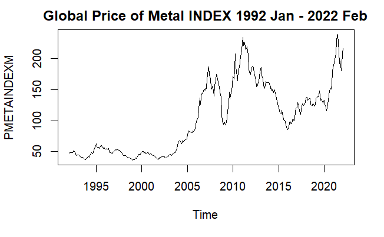

```r
PMETAINDEXM <- PMETAINDEXM[1:362]
PMETAINDEXM <- ts(PMETAINDEXM[,"PMETAINDEXM"],start=c(1992,1), frequency=12)
plot.ts(PMETAINDEXM, main="Global Price of Metal INDEX 1992 Jan - 2022 Feb")
```

```r
head(PMETAINDEXM, 10)
```

```
          Jan      Feb      Mar      Apr      May      Jun      Jul
1992 46.94867 48.31941 48.22012 48.62863 48.60557 48.72549 50.82103
          Aug      Sep      Oct
1992 50.47210 49.13035 45.97592
```

To identify an ARIMA model, the Box-Jenkins method was followed. This method uses the autocorrelations and partial autocorrelations of a series to identify the ARIMA model for estimation. The Box-Jenkins method has four general steps: Model Identification, Model Estimation, Model Evaluation, and finally Forecast. The properties of ACF and PACF of a series can guide us to identifying a tentative model. Once an ARIMA (or pure AR or MA) is identified, it is used to fit the time series data (Model Estimation). The evaluation step involves assessing the adequacy of the model using several statistical tests. The significance of the estimated coefficient(s) is checked, as well as checking the autocorrelations of the residuals and whether they amount into being just a white noise process. If the model is not adequate, then the method dictates re-identification (back to step 1).

**ARIMA (p,d,q)**

**p = order of autocorrelation (autoregressive term)**

**d= order of integration (differencing)**

**q= order of moving average**

Table 1: Properties of ACF, PACF for AR, MA & ARMA model identification:1

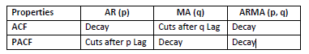

Table 1 shows the characteristics of the ACF and PACF graphs that can help us decide which model to choose.

However, ARIMA models makes an important assumption about the series, and that is the stationarity assumption. Simply put stationarity assumes that the mean and variance of a series are not dependent on time, or that they are constant over time. This assumption makes the test of unit root in a series a very important practice. This paper uses the Augmented Dickey-Fuller (ADF) test to test for the presence of unit root. The paper adopts the Ender’s approach (Enders & Lee, 2010) to test for unit root in the PMETAINDEXM series. After, stationarity is achieved, we identify a model and estimate. The process as laid out above is iterated several times to reach an adequate model that can be used for out-of-sample forecasting.

Several criteria’s help us decide in the best model for forecasting. This paper assesses several criteria to decide between several models for forecasting the global price of metals index. These fit statistics include Root Mean Squared Erorr (RMSE), Mean Absolute Error (MAE), Mean Absolute Percent Error (MAPE), Akaike Information Criterion (AIC), and Baysian Information Criterion (BIC). These criteria all need to be minimized in the best model for forecasting. Refer to Table 2 for the relevant formulas of the aforementioned criteria.

Table 2: Fit Statistics:

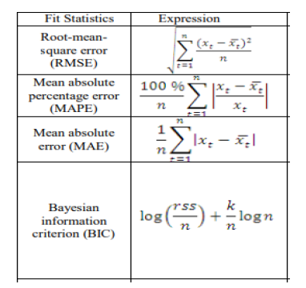

*Important Note: Tables 1 and 2 are adopted from Guha and Bandyopadhyay (2016)

[figure not shown]

**Results and Discussion:**

First is presented the results for the Augment Dickey Fuller test. The ADF test in its most general form is written as:

**Δy<sub>t</sub> = α<sub>0</sub> + θ <sub>yt-1</sub> + α<sub>2T</sub> + Σ β<sub>i</sub> Δ<sub>yt-i</sub> + ε<sub>t</sub>**

Where: T= Time trend, α<sub>0</sub> = Intercept (Drift), Σ β<sub>i</sub> Δ<sub>yt-I</sub> = lag augmentations of Δy<sub>t.</sub>

The null H0 : θ=0 is the hypothesis that the series has Unit root. The nature of most unit root tests, including the ADF test is biased to finding a unit root even at times when there isn’t (type 1 error). As mentioned before, the paper adopts the Ender’s approach (Enders & Lee, 2010), suggested by Walter Enders, to test for unit root using the ADF test. The results of this process are summarized in Table 3 below.

```r
adf <- ur.df(log(PMETAINDEXM), type="trend", lags=12) # type: "none", "drift", "trend"
summary(adf)
```

```
###############################################
# Augmented Dickey-Fuller Test Unit Root Test #
###############################################

Test regression trend


Call:
lm(formula = z.diff ~ z.lag.1 + 1 + tt + z.diff.lag)

Residuals:
      Min        1Q    Median        3Q       Max
-0.182313 -0.025192 -0.002514  0.027821  0.143178

Coefficients:
               Estimate Std. Error t value Pr(>|t|)
(Intercept)   0.0655468  0.0288521   2.272   0.0237 *
z.lag.1      -0.0177047  0.0078709  -2.249   0.0251 *
tt            0.0000877  0.0000439   1.998   0.0466 *
z.diff.lag1   0.3374655  0.0542974   6.215 1.53e-09 ***
z.diff.lag2  -0.0199247  0.0574454  -0.347   0.7289
z.diff.lag3   0.0459244  0.0575227   0.798   0.4252
z.diff.lag4   0.0236948  0.0580480   0.408   0.6834
z.diff.lag5   0.0456426  0.0582783   0.783   0.4341
z.diff.lag6   0.0109173  0.0585924   0.186   0.8523
z.diff.lag7  -0.0313785  0.0589320  -0.532   0.5948
z.diff.lag8  -0.0077456  0.0589377  -0.131   0.8955
z.diff.lag9  -0.0178686  0.0588969  -0.303   0.7618
z.diff.lag10  0.0676252  0.0591559   1.143   0.2538
z.diff.lag11  0.0668915  0.0592244   1.129   0.2595
z.diff.lag12 -0.0092006  0.0565748  -0.163   0.8709
---
Signif. codes:  0 ‘***’ 0.001 ‘**’ 0.01 ‘*’ 0.05 ‘.’ 0.1 ‘ ’ 1

Residual standard error: 0.04615 on 334 degrees of freedom
Multiple R-squared:  0.1367,    Adjusted R-squared:  0.1005
F-statistic: 3.777 on 14 and 334 DF,  p-value: 6.204e-06


Value of test-statistic is: -2.2494 2.1185 2.5585

Critical values for test statistics:
      1pct  5pct 10pct
tau3 -3.98 -3.42 -3.13
phi2  6.15  4.71  4.05
phi3  8.34  6.30  5.36
```

```r
diff.adf <- ur.df(diff(log(PMETAINDEXM)), type="trend", lags=2) # type: "none", "drift", "trend"
summary(diff.adf)
```

```
###############################################
# Augmented Dickey-Fuller Test Unit Root Test #
###############################################

Test regression trend


Call:
lm(formula = z.diff ~ z.lag.1 + 1 + tt + z.diff.lag)

Residuals:
      Min        1Q    Median        3Q       Max
-0.205740 -0.024397 -0.002521  0.029464  0.138180

Coefficients:
              Estimate Std. Error t value Pr(>|t|)
(Intercept)  9.546e-04  4.892e-03   0.195    0.845
z.lag.1     -6.571e-01  7.175e-02  -9.159   <2e-16 ***
tt           1.001e-05  2.342e-05   0.428    0.669
z.diff.lag1 -8.981e-04  6.413e-02  -0.014    0.989
z.diff.lag2 -3.739e-02  5.341e-02  -0.700    0.484
---
Signif. codes:  0 ‘***’ 0.001 ‘**’ 0.01 ‘*’ 0.05 ‘.’ 0.1 ‘ ’ 1

Residual standard error: 0.04578 on 353 degrees of freedom
Multiple R-squared:  0.3345,    Adjusted R-squared:  0.3269
F-statistic: 44.35 on 4 and 353 DF,  p-value: < 2.2e-16


Value of test-statistic is: -9.1588 27.9753 41.9593

Critical values for test statistics:
      1pct  5pct 10pct
tau3 -3.98 -3.42 -3.13
phi2  6.15  4.71  4.05
phi3  8.34  6.30  5.36
```

Table 3: Results of the ADF Test:

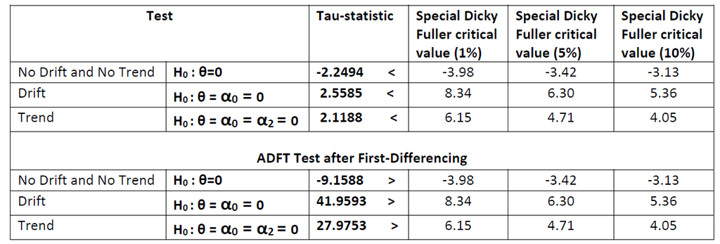

Table 3, top half, shows the ADF test results. The resulting special Dicky-Fuller t-statistics (called tau values) all fall within the “fail to reject” zones at significance levels of 1, 5 and 10%. This expected because visually we can see that the data is in fact trending (upwards), and hence the mean of the data is not constant across time. Hence, unlike (Adewuyi & Wahab & Adeboye, 2020), I find that there is unit root presence in in the series, and so the series is non-stationary. Hence, first difference of the series is taken to make it stationary, and then the ADF test is conducted again, and the results are shown in the second half of Table 3. The results show that there is no statistical evidence for the presence of unit root.

The plot below shows the eventual look of the series data in its stationary form.

Figure 2: A plot of Global Price of Metal Index 1992-2022 after Log Transformation and first-differencing

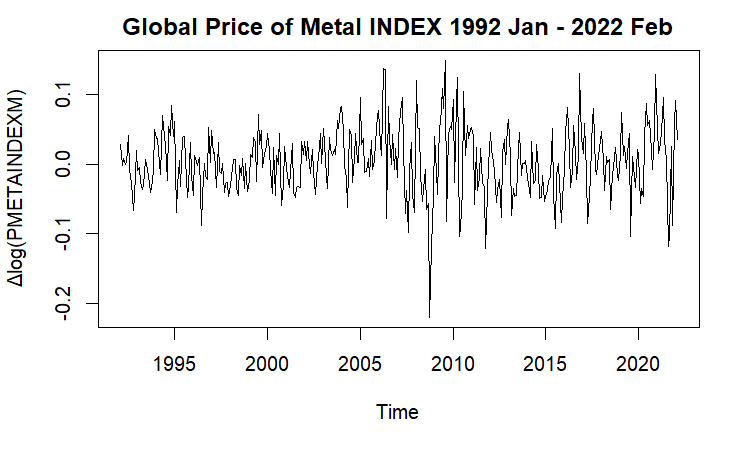

```r
plot.ts(diff(log(PMETAINDEXM)), ylab = "Δlog(PMETAINDEXM)" , main = "Global Price of Metal INDEX 1992 Jan - 2022 Feb")
```

It is also noteworthy to point out why a pre-differencing transformation technique is used prior to testing stationarity. As can be seen on Figure 1 plot of the original series, beside the time trend, the volatility of the price index is not constant, especially with large fluctuations that happen in the period of and after the 2008 financial crisis recession. The paper employs one of the more common transformation techniques and that is the logarithmic transformation, which helps to “knock down” the variance of the series. Figure 2 below show the difference between a first difference of the log-transformed data and the untransformed data. The log helps stabilize the variance and make the series more stationary. Hence, the log transformed data is adopted to analyze and fit the data for the rest of this paper.

Figure 2: The use of log-transformation technique to stabilize the variance:

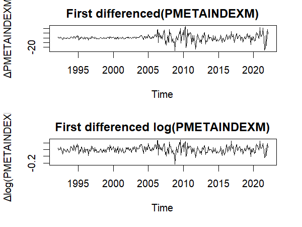

```r
Metal1<-PMETAINDEXM
Metal2<-log(PMETAINDEXM)
Metal <- diff(log(PMETAINDEXM))
par(mfrow=c(2,1))
plot.ts(diff(PMETAINDEXM), main="First differenced(PMETAINDEXM)", ylab="ΔPMETAINDEXM")
plot.ts(Metal, main="First differenced log(PMETAINDEXM)", ylab="Δlog(PMETAINDEXM)")
```

After assessing the ADF test results, first differencing is required to fit the model. After, the ACF (Correlogram) and the PACF plots are assessed to identify a model. Figure 3 shows the ACF and PACF graphs. At first glance, there is not a clear decaying pattern or quick cut off pattern to be followed. In fact, both the ACF and PACF seem to cut-off quickly. Hence, I try three different ARIMA (p,d,q) models: ARIMA (1,1,0), ARIMA (0,1,1), and finally ARIMA (1,1,1).

Figure 3: ACF and PACF plot:

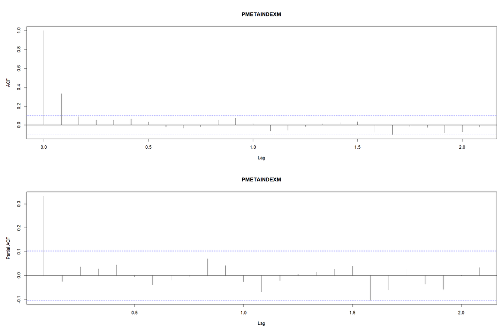

```r
par(mfrow=c(2,1), mai= c(1,1,1,0))
acf(Metal, main="PMETAINDEXM")
pacf(Metal, main="PMETAINDEXM")
```

```r
########################Trying out different ARIMA models################
####ARIMA(1,1,1)

result1 <- arima(Metal2[1:350], order=c(1,1,1))
summary(result1)
```

```
Call:
arima(x = Metal2[1:350], order = c(1, 1, 1))

Coefficients:
         ar1     ma1
      0.2732  0.0717
s.e.  0.1681  0.1765

sigma^2 estimated as 0.001984:  log likelihood = 590.56,  aic = -1175.12

Training set error measures:
                      ME       RMSE        MAE        MPE      MAPE
Training set 0.002754602 0.04448181 0.03356153 0.05849759 0.7466486
                  MASE         ACF1
Training set 0.9183852 -0.003637223
```

```r
coeftest1<- coeftest(result1)
summary(coeftest1)
```

```
    Estimate         Std. Error        z value          Pr(>|z|)
 Min.   :0.07171   Min.   :0.1681   Min.   :0.4062   Min.   :0.1041
 1st Qu.:0.12208   1st Qu.:0.1702   1st Qu.:0.7109   1st Qu.:0.2493
 Median :0.17246   Median :0.1723   Median :1.0156   Median :0.3944
 Mean   :0.17246   Mean   :0.1723   Mean   :1.0156   Mean   :0.3944
 3rd Qu.:0.22284   3rd Qu.:0.1744   3rd Qu.:1.3204   3rd Qu.:0.5395
 Max.   :0.27321   Max.   :0.1765   Max.   :1.6251   Max.   :0.6846
```

```r
BIC(result1)
```

```
[1] -1163.55
```

```r
Metal.fitted.1 <- fitted(result1)   #result1$fitted.values
Metal.resid.1 <- result1$residuals
Metal_1 <- ts(Metal2[5:350],start=c(1992,1),frequency=12)
Metal.fitted.1 <- ts(Metal.fitted.1[5:350],start=c(1992,1),frequency=12)
Metal.resid.1 <- ts(Metal.resid.1[5:350],start=c(1992,1),frequency=12)
```

```r
####ARIMA(1,1,0)

result2 <- arima(Metal2[1:350], order=c(1,1,0))
summary(result2)
```

```
Call:
arima(x = Metal2[1:350], order = c(1, 1, 0))

Coefficients:
         ar1
      0.3371
s.e.  0.0503

sigma^2 estimated as 0.001985:  log likelihood = 590.48,  aic = -1176.96

Training set error measures:
                      ME      RMSE      MAE        MPE      MAPE
Training set 0.002695839 0.0444919 0.033587 0.05734448 0.7472055
                  MASE        ACF1
Training set 0.9190819 0.003265385
```

```r
coeftest2<- coeftest(result2)
summary(coeftest2)
```

```
    Estimate        Std. Error         z value         Pr(>|z|)
 Min.   :0.3371   Min.   :0.05031   Min.   :6.701   Min.   :2.07e-11
 1st Qu.:0.3371   1st Qu.:0.05031   1st Qu.:6.701   1st Qu.:2.07e-11
 Median :0.3371   Median :0.05031   Median :6.701   Median :2.07e-11
 Mean   :0.3371   Mean   :0.05031   Mean   :6.701   Mean   :2.07e-11
 3rd Qu.:0.3371   3rd Qu.:0.05031   3rd Qu.:6.701   3rd Qu.:2.07e-11
 Max.   :0.3371   Max.   :0.05031   Max.   :6.701   Max.   :2.07e-11
```

```r
BIC(result2)
```

```
[1] -1169.248
```

```r
Metal.fitted.2 <- fitted(result2) #result1$fitted.values
Metal.resid.2 <- result2$residuals
Metal_2 <- ts(Metal2[5:350],start=c(1992,1),frequency=12)
Metal.fitted.2 <- ts(Metal.fitted.2[5:350],start=c(1992,1),frequency=12)
Metal.resid.2 <- ts(Metal.resid.2[5:350],start=c(1992,1),frequency=12)
```

```r
####ARIMA(0,1,1)

result3 <- arima(Metal2[1:350], order=c(0,1,1))
summary(result3)
```

```
Call:
arima(x = Metal2[1:350], order = c(0, 1, 1))

Coefficients:
         ma1
      0.3227
s.e.  0.0474

sigma^2 estimated as 0.001999:  log likelihood = 589.29,  aic = -1174.59

Training set error measures:
                      ME       RMSE        MAE       MPE      MAPE
Training set 0.003066744 0.04464381 0.03366402 0.0646837 0.7488394
                  MASE       ACF1
Training set 0.9211896 0.02182353
```

```r
coeftest3<- coeftest(result3)
summary(coeftest3)
```

```
    Estimate        Std. Error         z value         Pr(>|z|)
 Min.   :0.3227   Min.   :0.04738   Min.   :6.811   Min.   :9.708e-12
 1st Qu.:0.3227   1st Qu.:0.04738   1st Qu.:6.811   1st Qu.:9.708e-12
 Median :0.3227   Median :0.04738   Median :6.811   Median :9.708e-12
 Mean   :0.3227   Mean   :0.04738   Mean   :6.811   Mean   :9.708e-12
 3rd Qu.:0.3227   3rd Qu.:0.04738   3rd Qu.:6.811   3rd Qu.:9.708e-12
 Max.   :0.3227   Max.   :0.04738   Max.   :6.811   Max.   :9.708e-12
```

```r
BIC(result3)
```

```
[1] -1166.879
```

```r
Metal.fitted.3 <- fitted(result3) #result1$fitted.values
Metal.resid.3 <- result3$residuals
Metal_3 <- ts(Metal2[5:350],start=c(1992,1),frequency=12)
Metal.fitted.3 <- ts(Metal.fitted.3[5:350],start=c(1992,1),frequency=12)
Metal.resid.3 <- ts(Metal.resid.3[5:350],start=c(1992,1),frequency=12)
```

Table 4: Statistical Fits for ARIMA models attempted

[figure not shown]

Figure 4: ARIMA (1,1,1) Model Fit and Residual Plot

```r
par(mfrow=c(1,2), mai= c(1,1.3,2,0))
plot(Metal_1,type="l", yaxt='n', ylim=c(3,6), xlab="Time",ylab="Log(PMETAINDEXM)",col="black", main="ARIMA(1,1,1)") +
lines(Metal.fitted.1, col="red", lty=1)
```

```
integer(0)
```

```r
axis(side=2,at=seq(3,6, by=1),lab=seq(3,6, by=1),cex.axis=0.8)
```

```r
par(new=T)
plot(Metal.resid.1,col="blue", axes=FALSE, ylim=c(-1.5,1.5), xlab="",ylab="")
```

```r
abline(h=0,col="black")
abline(h=0.1,col="black",lty="dashed")
```

```r
abline(h=-0.1,col="black",lty="dashed")
axis(side=4,at=seq(-0.3,0.3, by=0.1),lab=seq(-0.3,0.3, by=0.1) ,cex.axis=0.6)
```

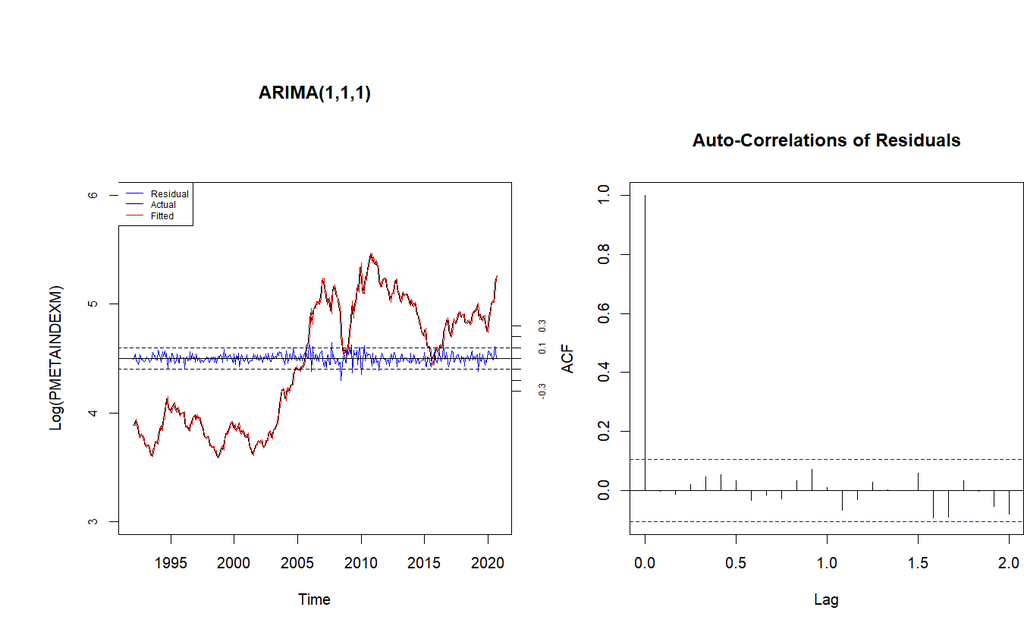

```r
legend("topleft",c("Residual","Actual","Fitted"),lty=c(1,1),col=c("blue","black","red"),cex=0.6)
acf(Metal.resid.1, main = "Auto-Correlations of Residuals", xlim=c(0,2))
```

Figure 5: Pseudo-Out-of-Sample Forecasting Vs. Actual Values of PMETAINDEXM

```r
ARIMA.predict <- predict(arima(Metal2[1:350], order=c(1,1,1)), n.ahead = 12)
ARIMA.forecast <- ARIMA.predict$pred
ARIMA.Forecast.lower <- NULL
ARIMA.Forecast.upper <- NULL
for (i in seq_along(ARIMA.forecast)) {
ARIMA.Forecast.lower[36+i] <- ARIMA.forecast[i]-(ARIMA.predict$se[i]*1.96)
ARIMA.Forecast.upper[36+i] <- ARIMA.forecast[i]+(ARIMA.predict$se[i]*1.96)
}
Metal.history <- Metal2[314:361]
Metal.history <- as.ts(Metal.history, frequency=12)
Metal.forecast <- NULL
for (j in seq_along(ARIMA.forecast)) {
Metal.forecast[36+j] <- ARIMA.forecast[j]
}
Metal.forecast <- as.ts(Metal.forecast, frequency=12)
par(mfrow=c(1,1))
plot(Metal.history, type="l",xlim=c(0,48),ylim=c(3,7), ylab="Log(PMETAINDEXM)",xlab="Time",axes=F, main="PMETAINDEXM: ARIMA (1,1,1) Forecast and History")
lines(Metal.forecast, col="blue")
```

```r
12
```

```
[1] 12
```

```r
lines(ARIMA.Forecast.lower,col="red",lty=2)
lines(ARIMA.Forecast.upper,col="red",lty=2)
```

```r
box()
axis(side=1, at=seq(0,48, by=2), lab=seq(0,48, by=2)) #,2,3,4,5,6,7,8,9,10,11,12,13,14,15,16,17,18,19,20,21,22,23,24,25,26,27,28,29,30,31,32,33,34,35,36,37))
```

```r
axis(side=2, at=seq(3,7,by=1))
abline(v=37,lty="dashed")
```

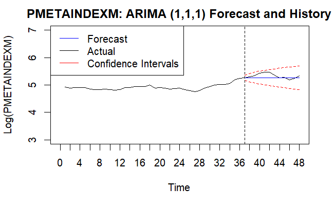

```r
legend("topleft",c("Forecast","Actual","Confidence Intervals"),lty=c(1,1),col=c("blue","black","red"),cex=1)
```

Figure 6 shows the final forecast of the next 6 months (March - August of 2022) for the global price of metals Index using ARIMA (1,1,1).

Figure 6: 6-month Horizon forecast of Global Price of Metal Index using ARIMA (1,1,1)

```r
#####################6 months Forecast by ARIMA(1,1,1) Model: graph of whole sample###########
ARIMA.predict <- predict(arima(Metal2[1:362], order=c(1,1,1)), n.ahead = 6)
ARIMA.forecast <- ARIMA.predict$pred
ARIMA.Forecast.lower <- NULL
ARIMA.Forecast.upper <- NULL
13
```

```
[1] 13
```

```r
for (i in seq_along(ARIMA.forecast)) {
ARIMA.Forecast.lower[200+i] <- ARIMA.forecast[i]-(ARIMA.predict$se[i]*1.96)
ARIMA.Forecast.upper[200+i] <- ARIMA.forecast[i]+(ARIMA.predict$se[i]*1.96)
}
Metal.history <- Metal2[162:362]
Metal.history <- as.ts(Metal.history, frequency=12)
Metal.forecast <- NULL
for (j in seq_along(ARIMA.forecast)) {
Metal.forecast[200+j] <- ARIMA.forecast[j]
}
Metal.forecast <- as.ts(Metal.forecast, frequency=12)
par(mfrow=c(1,1))
plot(Metal.history, type="l",xlim=c(0,207),ylim=c(3,7), ylab="Log(PMETAINDEXM)",xlab="Time",axes=F, main="PMETAINDEXM: ARIMA (1,1,1) 6 months ahead Forecast")
lines(Metal.forecast, col="blue")
```

```r
lines(ARIMA.Forecast.lower,col="red",lty=2)
lines(ARIMA.Forecast.upper,col="red",lty=2)
```

```r
box()
axis(side=1, at=seq(0,206, by=20), lab=seq(0,206, by=20)) #,2,3,4,5,6,7,8,9,10,11,12,13,14,15,16,17,18,19,20,21,22,23,24,25,26,27,28,29,30,31,32,33,34,35,36,37))
```

```r
axis(side=2, at=seq(3,7,by=1))
abline(v=201,lty="dashed")
```

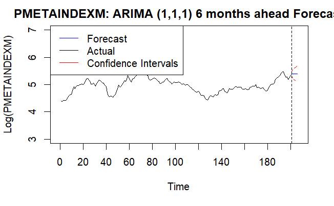

```r
legend("topleft",c("Forecast","Actual","Confidence Intervals"),lty=c(1,1),col=c("blue","black","red"),cex=1)
```

```r
#####################6 months Forecast by ARIMA(1,1,1) Model###########
ARIMA.predict <- predict(arima(Metal2[1:362], order=c(1,1,1)), n.ahead = 6)
ARIMA.forecast <- ARIMA.predict$pred
ARIMA.Forecast.lower <- NULL
ARIMA.Forecast.upper <- NULL
for (i in seq_along(ARIMA.forecast)) {
ARIMA.Forecast.lower[24+i] <- ARIMA.forecast[i]-(ARIMA.predict$se[i]*1.96)
ARIMA.Forecast.upper[24+i] <- ARIMA.forecast[i]+(ARIMA.predict$se[i]*1.96)
}
Metal.history <- Metal2[338:362]
Metal.history <- as.ts(Metal.history, frequency=12)
Metal.forecast <- NULL
for (j in seq_along(ARIMA.forecast)) {
Metal.forecast[24+j] <- ARIMA.forecast[j]
}
Metal.forecast <- as.ts(Metal.forecast, frequency=12)
par(mfrow=c(1,1))
plot(Metal.history, type="l",xlim=c(0,30),ylim=c(3,7), ylab="Log(PMETAINDEXM)",xlab="Time",axes=F, main="PMETAINDEXM: ARIMA (1,1,1) 6 months ahead Forecast")
lines(Metal.forecast, col="blue")
```

```r
lines(ARIMA.Forecast.lower,col="red",lty=2)
lines(ARIMA.Forecast.upper,col="red",lty=2)
```

```r
box()
axis(side=1, at=seq(0,30, by=4), lab=seq(0,30, by=4)) #,2,3,4,5,6,7,8,9,10,11,12,13,14,15,16,17,18,19,20,21,22,23,24,25,26,27,28,29,30,31,32,33,34,35,36,37))
```

```r
axis(side=2, at=seq(3,7,by=1))
abline(v=25,lty="dashed")
```

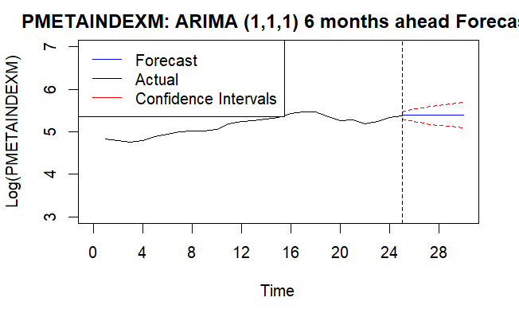

```r
legend("topleft",c("Forecast","Actual","Confidence Intervals"),lty=c(1,1),col=c("blue","black","red"),cex=1)
```

**Important Note:**

Please note that the forecasting of the data is done using the log-transformed data, since that is the data I used to fit the model. Hence why the first graph of the forecast does not resemble the original data plot (figure 1).

**Conclusion:**

Given the importance of metal to world economy, governments, corporations and individual investors, it is vital that their future movements are predicted and managed. One way of forecasiting metal prices at a global level is to use global data. One such series is the “PMETAINDEXM” (FRED) for the Global Price of Metal Index (base metals). Using a time series model (ARIMA (p,d,q)), this paper adequately estimates and makes a 6 moth ahead forecast of the series. The Box-Jinkins method is used to identify, estimate, evaluate and forecast the time series.

I suggest further study to be done in the unit root process that exist in the index despite previous research showing that the price of individual metals is stationary. Further investigations should explore the short to medium term implications of the non-stationarity (unit-root) of the index.

I should also point to the obvious inadequacy of ARIMA models being linear models. ARIMAs fail to predict turning points, as can be seen from the prediction made on the test data in figure 5. *(I think it would be interesting to run this data through some machine learning models and compare the performance metrics against ARIMA.)*

Another important note here is that there is clearly a subjective component when deciding on the best model to use for estimation. So, perhaps other people can also try to fit different models and see if they can obtain better results.

**References:**

Adewuyi, O.A., & Wahab, A.B., Adeboye, S.O (2020, March). Stationarity of prices of precious and industrial metals using recent unit root methods: Implications for markets’ efficiency. Resources Policy. Retrieved May 13, 2022, from https://www.sciencedirect.com/science/article/abs/pii/S0301420719305987?via%3Dihubhttps://www.mdpi.com/2571-9394/3/2/27

Dooley, G., & Lenihan, H. (2005, September). An assessment of time series methods in metal price forecasting. Resources Policy. Retrieved May 13, 2022, from https://www.sciencedirect.com/science/article/abs/pii/S0301420705000413

Enders, W., & Lee, J. (2010, April 18). A unit root test using a Fourier … - wenders.people.ua.edu. Wenders.people.ua.edu. Retrieved May 14, 2022, from https://wenders.people.ua.edu/uploads/2/6/3/8/26382715/enders_lee_april_18_2010.pdf

FRED: https://fred.stlouisfed.org/series/PMETAINDEXMR

Guha, B., & Bandyopadhyay, G., (2016, March). Gold Price Forecasting Using ARIMA Model. Journal of Advanced Management Science. Retrieved May 13, 2022, from http://www.joams.com/uploadfile/2015/0407/20150407040907791.pdf27

Kwas, M., & Rubaszek, M. (2021, June 19). Forecasting commodity prices: Looking for a benchmark. MDPI. Retrieved May 13, 2022, from https://www.mdpi.com/2571-9394/3/2/27